# Análisis de Anomalías en Patentes Vehiculares

Comuna de Arica - Enero 2025

Author

Equipo de Análisis de Datos

Published

March 2, 2025

# Resumen Ejecutivo

Este informe presenta los resultados de un análisis avanzado de detección de anomalías en los datos de patentes vehiculares de la Comuna de Arica para enero de 2025. Utilizando técnicas de aprendizaje automático (Isolation Forest), se identificaron patrones inusuales en las operaciones diarias que podrían requerir atención especial.

**Principales hallazgos:**

- Se identificaron **5** días con comportamientos anómalos.
- Las anomalías extremas se presentaron principalmente los días **miércoles, domingo**.
- Los cambios porcentuales abruptos en el número de transacciones y montos totales fueron los principales indicadores de anomalías.

# 1. Introducción

## 1.1 Contexto

El análisis de patentes vehiculares proporciona información valiosa sobre la flota vehicular de la comuna y sobre los patrones de pago de los ciudadanos. La detección de anomalías en estos datos puede ayudar a:

- Identificar días con comportamientos inusuales para investigación
- Mejorar la planificación de recursos en módulos de atención
- Detectar posibles inconsistencias administrativas o técnicas
- Comprender mejor los patrones estacionales y tendencias

## 1.2 Objetivos del Análisis

- Caracterizar la distribución normal de pagos de patentes vehiculares
- Identificar y clasificar anomalías en los patrones diarios
- Determinar qué factores contribuyen más a la detección de anomalías
- Proporcionar recomendaciones basadas en los hallazgos

## 1.3 Metodología

Se aplicó un enfoque de detección de anomalías multidimensional que consideró:

1. **Extracción de características**: Incluyendo estadísticas temporales, composición de la flota, y canales de pago
2. **Análisis contextual**: Z-scores específicos por día de la semana
3. **Modelado con Isolation Forest**: Algoritmo no supervisado especializado en detección de valores atípicos
4. **Clasificación de anomalías**: En niveles “Moderada” y “Extrema” según su puntuación

# 2. Exploración de Datos

## 2.1 Composición de la Flota Vehicular

La flota vehicular de Arica está principalmente compuesta por station wagons, automóviles y camionetas, con un predominio de marcas asiáticas.

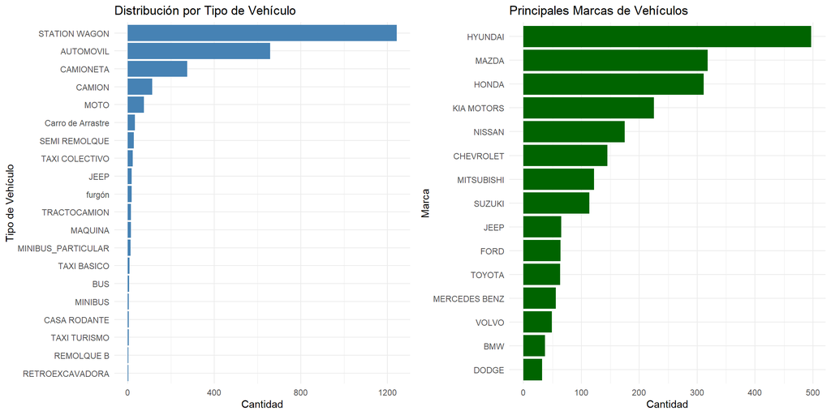

La distribución muestra claramente que los station wagon son el tipo de vehículo más común en Arica, seguidos por automóviles y camionetas. En cuanto a marcas, Hyundai lidera con una ventaja considerable, seguida por Mazda, Honda y Kia Motors.

## 2.2 Antigüedad y Montos

La antigüedad promedio de los vehículos es un factor importante que influye en los montos pagados por patentes.

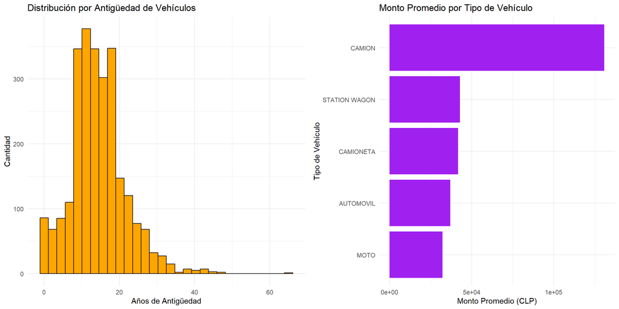

El histograma de antigüedad muestra que la mayoría de los vehículos tienen entre 10 y 20 años, con una concentración notable alrededor de los 15 años. En cuanto a los montos, los camiones tienen las patentes más costosas, seguidos por los station wagon, camionetas y automóviles.

## 2.3 Series Temporales de Indicadores Clave

A lo largo del mes, observamos variaciones significativas en varios indicadores clave.

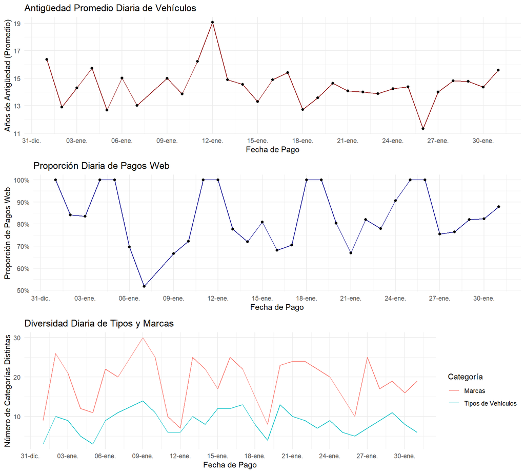

Estas series temporales revelan patrones interesantes:

- **Antigüedad promedio**: Varía entre 11 y 19 años a lo largo del mes, con un pico notable el 12 de enero.
- **Proporción de pagos web**: Presenta oscilaciones significativas, con días de 100% web y otros con apenas 50%.
- **Diversidad de tipos y marcas**: Las marcas muestran mayor variabilidad que los tipos de vehículos, con un pico significativo el 9 de enero.

# 3. Detección de Anomalías

## 3.1 Distribución de Puntuaciones

El modelo de Isolation Forest asignó puntuaciones de anomalía a cada día, con valores más altos indicando mayor probabilidad de ser una anomalía.

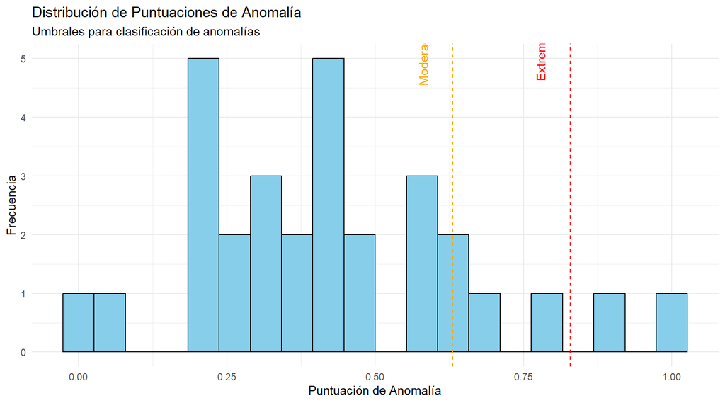

La distribución de puntuaciones muestra una clara separación entre días normales y anómalos. Los umbrales establecidos (líneas naranja y roja) permiten clasificar las anomalías en moderadas y extremas.

## 3.2 Anomalías en Series Temporales

Las anomalías detectadas se visualizan en el contexto de las series temporales de montos y número de transacciones.

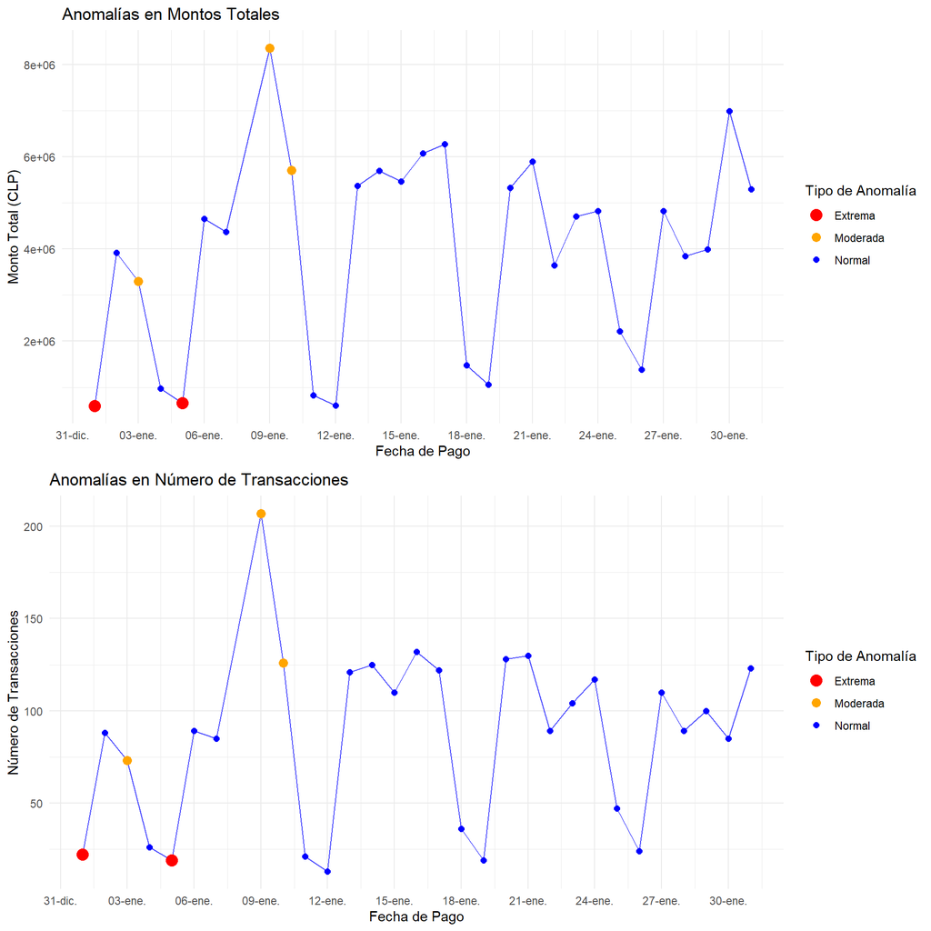

Observamos que el pico de transacciones y montos del 9 de enero fue clasificado como anomalía moderada, junto con el 10 de enero y el 3 de enero. Las anomalías extremas corresponden al 1 y 5 de enero, caracterizadas por valores muy bajos.

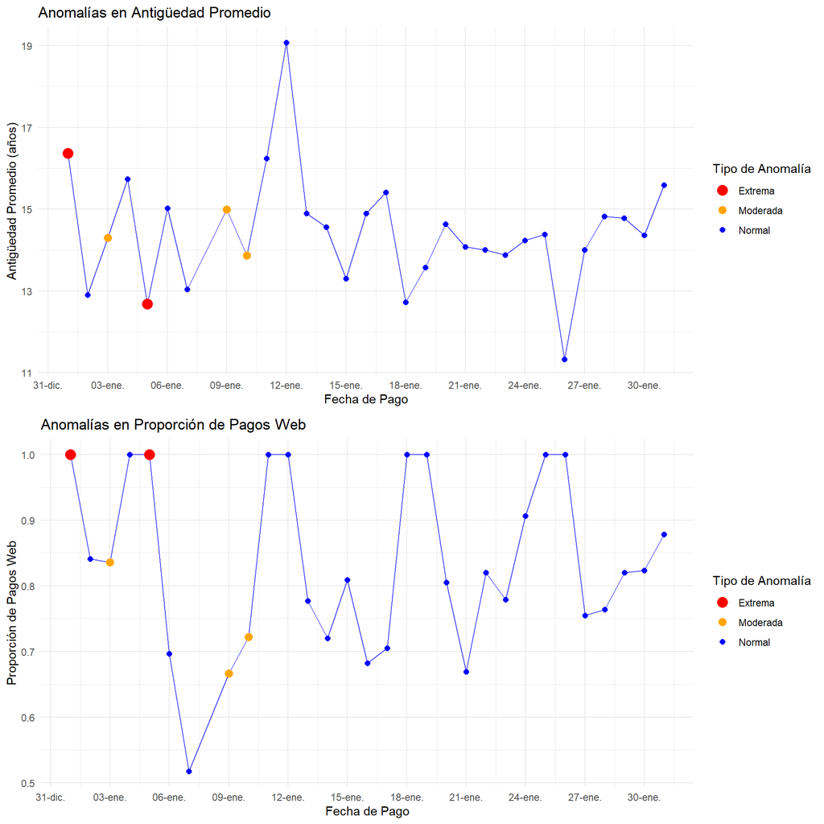

En cuanto a la antigüedad promedio, se detectó una anomalía extrema el 1 de enero (valor alto) y otra el 5 de enero (valor bajo). La proporción de pagos web muestra anomalías extremas los días con 100% de pagos web.

## 3.3 Relaciones Multidimensionales

Las anomalías también se pueden observar en relaciones entre variables.

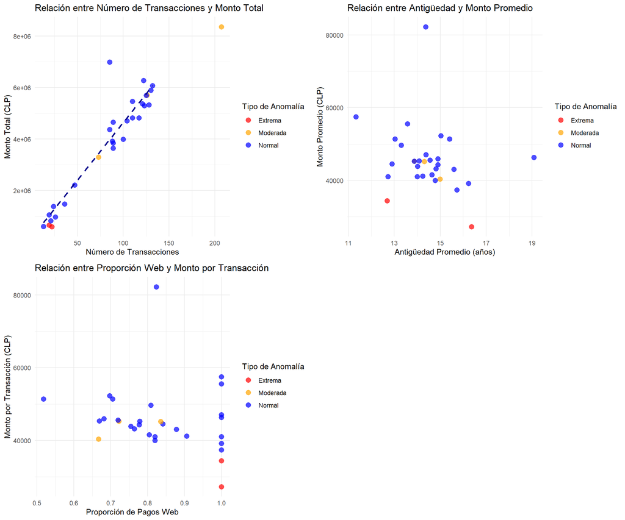

Estas visualizaciones revelan que:

- Existe una relación lineal clara entre número de transacciones y monto total, con el 9 de enero destacándose como una anomalía moderada.
- La relación entre antigüedad y monto promedio muestra dos anomalías extremas con valores atípicamente bajos.
- Los días con 100% de pagos web incluyen anomalías extremas con montos por transacción significativamente bajos.

## 3.4 Composición por Tipo de Vehículo

La mezcla de tipos de vehículos también presenta patrones anómalos en ciertos días.

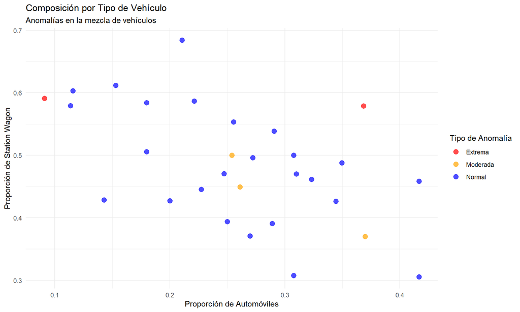

Se observa que las anomalías extremas se asocian con proporciones inusuales de automóviles y station wagons, alejadas del patrón típico de la mayoría de los días.

# 4. Análisis de Anomalías Detectadas

## 4.1 Factores Contribuyentes

Las características que más contribuyeron a la detección de anomalías fueron los cambios porcentuales en transacciones y montos.

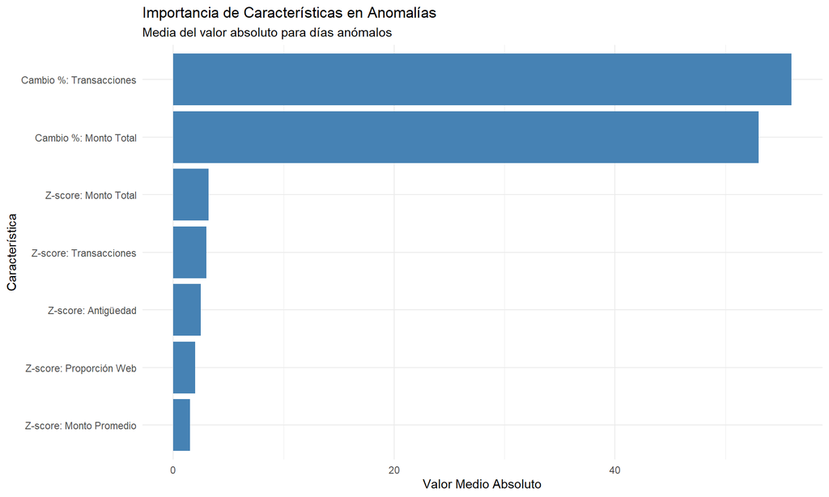

El análisis de importancia de características muestra claramente que los cambios porcentuales en el número de transacciones y en los montos totales son los factores más determinantes para detectar anomalías, muy por encima de otros indicadores como los Z-scores.

## 4.2 Detalle de Anomalías

A continuación se presenta la lista detallada de días con comportamientos anómalos.

| Fecha | Día | Monto Total | Transacciones | Monto Promedio | Antigüedad | % Web | Tipo Anomalía | Puntuación |
| --- | --- | --- | --- | --- | --- | --- | --- | --- |
| 01-ene.-2025 | miércoles | 600406 | 22 | 27291 | 16.4 | 100.0% | Extrema | 1.000 |
| 05-ene.-2025 | domingo | 654373 | 19 | 34441 | 12.7 | 100.0% | Extrema | 0.878 |
| 09-ene.-2025 | jueves | 8358706 | 207 | 40380 | 15.0 | 66.7% | Moderada | 0.769 |
| 10-ene.-2025 | viernes | 5705087 | 126 | 45278 | 13.9 | 72.2% | Moderada | 0.695 |
| 03-ene.-2025 | viernes | 3301034 | 73 | 45220 | 14.3 | 83.6% | Moderada | 0.639 |

## 4.3 Perfil de Días Anómalos vs. Normales

[output not shown]

# 5. Hallazgos Principales

## 5.1 Patrones de Anomalías

Del análisis realizado, se pueden identificar tres tipos principales de anomalías:

1. **Picos de volumen**: Especialmente notable el 9 de enero, con un número de transacciones (207) y monto total (~8.3 millones CLP) muy superiores al promedio.
2. **Días de bajo volumen**: El 1 y 5 de enero presentan un número inusualmente bajo de transacciones, clasificados como anomalías extremas.
3. **Anomalías de composición**: Días con una mezcla inusual de tipos de vehículos o proporciones atípicas de pagos web versus presenciales.

## 5.2 Factores Determinantes

Los factores más determinantes para detectar anomalías fueron:

1. **Cambios porcentuales en transacciones**: El cambio día a día en el número de operaciones.
2. **Cambios porcentuales en montos**: Variaciones bruscas en los montos totales recaudados.
3. **Z-scores contextuales**: Desviaciones respecto a lo esperado para cada día de la semana.

## 5.3 Características Distintivas

Las anomalías extremas se caracterizan por:

- Número muy bajo de transacciones (promedio 20.5 vs. 85.3 en días normales)
- Montos por transacción significativamente menores (30.866 vs. 47.034 en días normales)
- 100% de pagos realizados por web

# 6. Conclusiones y Recomendaciones

## 6.1 Conclusiones

- La detección multidimensional de anomalías permite identificar comportamientos inusuales que podrían pasar desapercibidos con métodos tradicionales.
- Los días de inicio de mes y algunos fines de semana presentan comportamientos particulares que los distinguen del resto.
- Las variaciones abruptas en volumen y composición son los principales indicadores de anomalías.

## 6.2 Recomendaciones

1. **Investigar causas específicas**: En particular, examinar el pico del 9 de enero para entender qué factores contribuyeron a un volumen tan alto de transacciones.
2. **Monitoreo continuo**: Implementar un sistema de monitoreo continuo que alerte sobre anomalías en tiempo real.
3. **Planificación de recursos**: Ajustar la disponibilidad de personal en módulos de atención según los patrones identificados, especialmente considerando que los días con 100% de pagos web coinciden con anomalías extremas.
4. **Análisis comparativo**: Expandir este análisis a otros meses y años para establecer patrones estacionales más robustos.

## 6.3 Próximos Pasos

- Integrar datos adicionales como eventos locales, feriados o campañas que puedan explicar algunas de las anomalías detectadas.
- Refinar el modelo para que diferencie entre anomalías operativas normales (como inicio de mes) y anomalías que requieren investigación.
- Desarrollar un dashboard interactivo para el monitoreo continuo de estos patrones.

# 7. Anexos

## 7.1 Metodología Detallada

Se utilizó el algoritmo de Isolation Forest implementado en H2O con los siguientes parámetros:

- **Número de árboles**: 150
- **Profundidad máxima**: 15
- **Tasa de muestreo**: 0.8
- **Semilla aleatoria**: 123

Las características utilizadas para el modelo incluyeron:

- Montos totales y número de transacciones
- Estadísticas de antigüedad de vehículos
- Proporciones por tipo de vehículo y canal de pago
- Z-scores contextuales por día de la semana
- Características derivadas (cambios, ratios, etc.)

## 7.2 Detalles de Implementación

La implementación del modelo de detección de anomalías se realizó siguiendo estos pasos:

```r
# Construir modelo de Isolation Forest con características ampliadas
features <- c(
  "total",
  "n",
  "dia_semana",
  "antiguedad_promedio",
  "antiguedad_max",
  "monto_promedio",
  "monto_mediana",
  "prop_automovil",
  "prop_station_wagon",
  "prop_camioneta",
  "prop_web",
  "tipos_distintos",
  "marcas_distintas",
  "log_total",
  "log_n",
  "monto_por_transaccion",
  "zscore_total",
  "zscore_n",
  "zscore_monto_promedio",
  "zscore_antiguedad",
  "zscore_prop_web",
  "cambio_total",
  "cambio_n",
  "prop_total",
  "prop_cuota"
)

modelo_if <- h2o.isolationForest(
  training_frame = h2o_data,
  x = features,
  sample_rate = 0.8,
  ntrees = 150,
  max_depth = 15,
  seed = 123
)

# Obtener puntuaciones de anomalía y clasificar
scores <- h2o.predict(modelo_if, h2o_data)
scores_df <- as.data.frame(scores)

# Añadir puntuaciones al dataframe original
patents_con_scores <- patents_enriched %>%
  bind_cols(anomaly_score = scores_df$predict)

# Determinar umbrales para dos niveles de anomalías
umbral_anomalia_extrema <- quantile(patents_con_scores$anomaly_score, 0.95) # Top 5%
umbral_anomalia_moderada <- quantile(patents_con_scores$anomaly_score, 0.85) # Top 15%

# Clasificar las instancias con niveles de anomalía
patents_con_scores <- patents_con_scores %>%
  mutate(
    tipo_anomalia = case_when(
      anomaly_score > umbral_anomalia_extrema ~ "Extrema",
      anomaly_score > umbral_anomalia_moderada ~ "Moderada",
      TRUE ~ "Normal"
    ),
    es_anomalia = tipo_anomalia != "Normal"
  )
```

## 7.3 Limitaciones del Análisis

Este análisis presenta algunas limitaciones que deben tenerse en cuenta:

1. **Período limitado**: Al considerar solo un mes de datos, no se capturan patrones estacionales más amplios.
2. **Datos agregados**: Al trabajar con datos diarios, pueden ocultarse anomalías a nivel de transacciones individuales.
3. **Contexto externo**: No se han incorporado factores externos como feriados, campañas especiales o eventos locales que podrían explicar algunas anomalías.
4. **Ajuste de umbrales**: Los umbrales para clasificar anomalías son arbitrarios (percentiles 85 y 95) y podrían ajustarse según necesidades específicas.

A pesar de estas limitaciones, el análisis proporciona información valiosa sobre patrones anómalos en el pago de patentes vehiculares que pueden ser útiles para la planificación y toma de decisiones.